# EDA Laboratório 1

Nesse lab. analisaremos as séries Breaking Bad, Hannibal e Sherlock, respondendo as seguintes perguntas:

1. Qual delas é mais bem avaliada no IMDB A diferença é grande? Pequena? Muda de acordo com as temporadas?
2. Qual das séries tem episódios de qualidade mais irregular segundo o IMDB? A diferença é grande? Pequena?
3. Episódios no início/fim da temporada são mais bem avaliados que os no meio? O que tende a ser melhor? Inícios ou finais de séries/temporadas?

```r
series = read_csv(here("data/series_from_imdb.csv"),
                    progress = FALSE,
                    col_types = cols(.default = col_double(),
                                     series_name = col_character(),
                                     episode = col_character(),
                                     url = col_character(),
                                     season = col_character())) %>%
    filter(series_name == "Breaking Bad" | series_name == "Sherlock" | series_name == "Hannibal")
```

# 1. Visão geral

Abaixo temos a visão geral das séries, mostrando a sua quantidade de episódios, temporadas e notas.

```r
series %>%
    filter(series_name == "Breaking Bad")
```

| series_name | episode | series_ep | season | season_ep | url | user_rating | user_votes | r1 | r2 | r3 | r4 | r5 | r6 | r7 | r8 | r9 | r10 |
| --- | --- | --- | --- | --- | --- | --- | --- | --- | --- | --- | --- | --- | --- | --- | --- | --- | --- |
| Breaking Bad | Pilot | 1 | 1 | 1 | http://www.imdb.com/title/tt0959621/ | 9.0 | 15067 | 0.05042463 | 0.001990446 | 0.0019240977 | 0.0029856688 | 0.006701168 | 0.012738854 | 0.048301486 | 0.138933121 | 0.25437898 | 0.4816215 |
| Breaking Bad | Cat's in the Bag... | 2 | 1 | 2 | http://www.imdb.com/title/tt1054724/ | 8.7 | 10364 | 0.02922454 | 0.001832562 | 0.0024112654 | 0.0047260802 | 0.010706019 | 0.018229167 | 0.078028549 | 0.240354938 | 0.24662423 | 0.3678627 |
| Breaking Bad | ...And the Bag's in the River | 3 | 1 | 3 | http://www.imdb.com/title/tt1054725/ | 8.7 | 10015 | 0.03552894 | 0.003093812 | 0.0021956088 | 0.0040918164 | 0.009680639 | 0.019461078 | 0.071856287 | 0.208982036 | 0.24421158 | 0.4008982 |
| Breaking Bad | Cancer Man | 4 | 1 | 4 | http://www.imdb.com/title/tt1054726/ | 8.3 | 9480 | 0.04903512 | 0.003269008 | 0.0024253928 | 0.0051671412 | 0.014341453 | 0.032479173 | 0.127069493 | 0.284825477 | 0.14636718 | 0.3350206 |
| Breaking Bad | Gray Matter | 5 | 1 | 5 | http://www.imdb.com/title/tt1054727/ | 8.4 | 9279 | 0.04739847 | 0.002585371 | 0.0033394377 | 0.0056016374 | 0.012495960 | 0.030593558 | 0.122805128 | 0.269524938 | 0.16169342 | 0.3439621 |
| Breaking Bad | Crazy Handful of Nothin' | 6 | 1 | 6 | http://www.imdb.com/title/tt1054728/ | 9.2 | 10838 | 0.04455309 | 0.002121576 | 0.0025827876 | 0.0017526058 | 0.005073333 | 0.006549211 | 0.027395997 | 0.100820957 | 0.25514251 | 0.5540079 |
| Breaking Bad | A No-Rough-Stuff-Type Deal | 7 | 1 | 7 | http://www.imdb.com/title/tt1054729/ | 8.8 | 9521 | 0.04944882 | 0.001889764 | 0.0022047244 | 0.0026246719 | 0.006824147 | 0.011023622 | 0.052388451 | 0.190761155 | 0.25984252 | 0.4229921 |
| Breaking Bad | Seven Thirty-Seven | 8 | 2 | 1 | http://www.imdb.com/title/tt1232244/ | 8.7 | 8578 | 0.03297215 | 0.002330188 | 0.0020971688 | 0.0044273564 | 0.008388675 | 0.017709426 | 0.081207037 | 0.245252243 | 0.23150414 | 0.3741116 |
| Breaking Bad | Grilled | 9 | 2 | 2 | http://www.imdb.com/title/tt1232245/ | 9.2 | 10096 | 0.03884838 | 0.003268796 | 0.0028916269 | 0.0054060850 | 0.010686447 | 0.023384461 | 0.098818205 | 0.230701534 | 0.20316822 | 0.3828263 |
| Breaking Bad | Bit by a Dead Bee | 10 | 2 | 3 | http://www.imdb.com/title/tt1232246/ | 8.4 | 8227 | 0.06124425 | 0.002178649 | 0.0027838296 | 0.0015734689 | 0.007504236 | 0.012708787 | 0.049382716 | 0.168724280 | 0.26095376 | 0.4329460 |

[output cut: 52 more lines]

```r
series %>%
    filter(series_name == "Sherlock")
```

| series_name | episode | series_ep | season | season_ep | url | user_rating | user_votes | r1 | r2 | r3 | r4 | r5 | r6 | r7 | r8 | r9 | r10 |
| --- | --- | --- | --- | --- | --- | --- | --- | --- | --- | --- | --- | --- | --- | --- | --- | --- | --- |
| Sherlock | Unaired Pilot | 1 | 1 | 1 | http://www.imdb.com/title/tt1664529/ | 8.9 | 7417 | 0.004505713 | 0.0030038084 | 0.0034865633 | 0.007455882 | 0.018291048 | 0.054604946 | 0.16193746 | 0.31899372 | 0.1824277 | 0.2452931 |
| Sherlock | A Study in Pink | 2 | 1 | 2 | http://www.imdb.com/title/tt1664530/ | 9.1 | 21659 | 0.002727940 | 0.0006819851 | 0.0009967475 | 0.002518099 | 0.003882069 | 0.011803588 | 0.04112895 | 0.12139335 | 0.3003357 | 0.5145315 |
| Sherlock | The Blind Banker | 3 | 1 | 3 | http://www.imdb.com/title/tt1665071/ | 8.1 | 18640 | 0.002954483 | 0.0007847844 | 0.0007847844 | 0.001569569 | 0.004154741 | 0.010617671 | 0.04214754 | 0.14112270 | 0.3328871 | 0.4629766 |
| Sherlock | The Great Game | 4 | 1 | 4 | http://www.imdb.com/title/tt1815240/ | 9.2 | 19060 | 0.008088434 | 0.0012132650 | 0.0013480723 | 0.002156916 | 0.006740361 | 0.020086277 | 0.06268536 | 0.16540847 | 0.2458884 | 0.4863845 |
| Sherlock | A Scandal in Belgravia | 5 | 2 | 1 | http://www.imdb.com/title/tt1942612/ | 9.6 | 27827 | 0.005964786 | 0.0011139059 | 0.0009701761 | 0.001652893 | 0.003485447 | 0.007689544 | 0.01940352 | 0.06068990 | 0.1768954 | 0.7221344 |
| Sherlock | The Hounds of Baskerville | 6 | 2 | 2 | http://www.imdb.com/title/tt1942613/ | 8.5 | 18578 | 0.004951561 | 0.0032831001 | 0.0033369214 | 0.005059203 | 0.013240043 | 0.032831001 | 0.11146394 | 0.24833154 | 0.2564586 | 0.3210441 |
| Sherlock | The Reichenbach Fall | 7 | 2 | 3 | http://www.imdb.com/title/tt1942614/ | 9.7 | 26791 | 0.005673124 | 0.0005598477 | 0.0007464636 | 0.001380958 | 0.002687269 | 0.005075953 | 0.01347367 | 0.04284701 | 0.1331318 | 0.7944239 |
| Sherlock | Many Happy Returns | 8 | 3 | 1 | http://www.imdb.com/title/tt2189771/ | 8.7 | 7580 | 0.011128776 | 0.0032226185 | 0.0032655867 | 0.004554634 | 0.010699093 | 0.021183346 | 0.05121815 | 0.11893611 | 0.2250677 | 0.5507240 |
| Sherlock | The Empty Hearse | 9 | 3 | 2 | http://www.imdb.com/title/tt2781042/ | 9.1 | 23270 | 0.011441879 | 0.0039995950 | 0.0050121507 | 0.006632240 | 0.014732685 | 0.025313892 | 0.05553868 | 0.12251924 | 0.2409376 | 0.5138720 |
| Sherlock | The Sign of Three | 10 | 3 | 3 | http://www.imdb.com/title/tt2781046/ | 9.0 | 19749 | 0.011480850 | 0.0034980716 | 0.0038568481 | 0.004439860 | 0.007668849 | 0.013454121 | 0.02906090 | 0.07018567 | 0.1732442 | 0.6831106 |

[output cut: 5 more lines]

```r
series %>%
    filter(series_name == "Hannibal")
```

| series_name | episode | series_ep | season | season_ep | url | user_rating | user_votes | r1 | r2 | r3 | r4 | r5 | r6 | r7 | r8 | r9 | r10 |
| --- | --- | --- | --- | --- | --- | --- | --- | --- | --- | --- | --- | --- | --- | --- | --- | --- | --- |
| Hannibal | Apéritif | 1 | 1 | 1 | http://www.imdb.com/title/tt2370419/ | 8.5 | 4491 | 0.007123776 | 0.0006678540 | 0.0020035619 | 0.0055654497 | 0.014692787 | 0.040071238 | 0.101959038 | 0.26313446 | 0.23775601 | 0.3270258 |
| Hannibal | Amuse-Bouche | 2 | 1 | 2 | http://www.imdb.com/title/tt2373019/ | 8.4 | 3716 | 0.006829268 | 0.0016260163 | 0.0019512195 | 0.0035772358 | 0.008130081 | 0.024390244 | 0.063089431 | 0.16747967 | 0.29821138 | 0.4247154 |
| Hannibal | Potage | 3 | 1 | 3 | http://www.imdb.com/title/tt2373021/ | 8.4 | 3418 | 0.008027923 | 0.0013961606 | 0.0013961606 | 0.0048865620 | 0.010820244 | 0.027923211 | 0.078184991 | 0.21256545 | 0.27050611 | 0.3842932 |
| Hannibal | Oeuf | 4 | 1 | 4 | http://www.imdb.com/title/tt2373023/ | 8.1 | 2822 | 0.008579272 | 0.0006863418 | 0.0010295127 | 0.0013726836 | 0.008922443 | 0.020247083 | 0.053534660 | 0.15442690 | 0.30233356 | 0.4488675 |
| Hannibal | Coquilles | 5 | 1 | 5 | http://www.imdb.com/title/tt2373025/ | 8.2 | 3146 | 0.008136925 | 0.0011223345 | 0.0014029181 | 0.0008417508 | 0.005611672 | 0.012906846 | 0.031144781 | 0.09708193 | 0.24803591 | 0.5937149 |
| Hannibal | Entrée | 6 | 1 | 6 | http://www.imdb.com/title/tt2373027/ | 8.7 | 3007 | 0.006996771 | 0.0008073197 | 0.0016146394 | 0.0061894510 | 0.013724435 | 0.045209903 | 0.113832078 | 0.29386437 | 0.20667384 | 0.3110872 |
| Hannibal | Sorbet | 7 | 1 | 7 | http://www.imdb.com/title/tt2373029/ | 8.9 | 3174 | 0.007899356 | 0.0023405500 | 0.0020479813 | 0.0040959626 | 0.017261556 | 0.043885313 | 0.124634289 | 0.28876536 | 0.18256290 | 0.3265067 |
| Hannibal | Fromage | 8 | 1 | 8 | http://www.imdb.com/title/tt2373031/ | 9.1 | 3187 | 0.007441531 | 0.0014174344 | 0.0017717931 | 0.0095676825 | 0.023387668 | 0.065910702 | 0.186392629 | 0.27391921 | 0.10418143 | 0.3260099 |
| Hannibal | Trou Normand | 9 | 1 | 9 | http://www.imdb.com/title/tt2373033/ | 8.5 | 2928 | 0.006993007 | 0.0019071837 | 0.0025429116 | 0.0069930070 | 0.016211062 | 0.057533376 | 0.151621106 | 0.28607756 | 0.14399237 | 0.3261284 |
| Hannibal | Buffet Froid | 10 | 1 | 10 | http://www.imdb.com/title/tt2373035/ | 8.9 | 3075 | 0.006651147 | 0.0013302295 | 0.0023279016 | 0.0016627868 | 0.009311606 | 0.027269704 | 0.081143997 | 0.22580645 | 0.28234120 | 0.3621550 |

[output cut: 29 more lines]

# 2. Qual a série com a melhor avaliação?

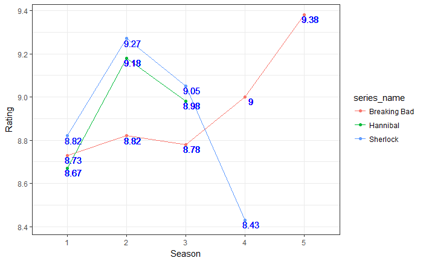

```r
seriesBySeason <- series %>%
    group_by(series_name, season) %>%
    mutate (season_rating = round(mean(user_rating), 2))
ggplot(seriesBySeason, aes(x = season, y = season_rating, group = series_name, label = season_rating, color = series_name)) +
       geom_line() +
       geom_point() +
       geom_text(nudge_x = .1, nudge_y = -.02, color = "blue") +
       labs(y = "Rating", x = "Season")
```

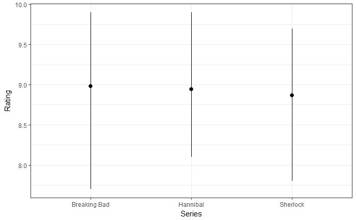

```r
ggplot(series, aes(x = series_name, y = user_rating)) +

    stat_summary(
        fun.ymin = min,
        fun.ymax = max,
        fun.y = mean
    ) +
    labs(y = "Rating", x = "Series")
```

A diferença entre suas notas gerais é bem baixa.

## 2.1 Quais séries tem qualidade mais irregular?

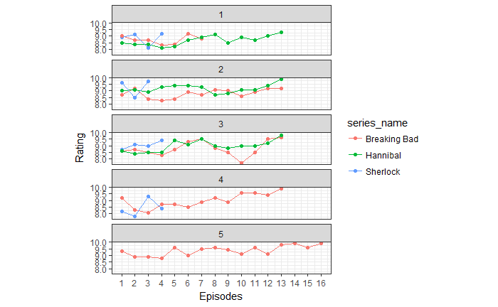

```r
ggplot(seriesBySeason, aes(x = season_ep, y = user_rating, group = series_name, label = season_rating, color = series_name)) +
       geom_line() +
       geom_point() +
       facet_wrap(~season, nrow = 5) +
       scale_x_continuous(breaks = (1:16)) +
       labs(y = "Rating", x = "Episodes") +
       coord_fixed()
```

Observando as avaliações da séries por episódios não é díficil perceber uma correlação positiva e linear entre os episódios da temporada e suas notas para Breaking Bad e Hannibal, isto é, por mais existam algumas exceções (pontos fora da curva), podemos observar que eles tendem a formar uma linha crescente indicando que os episódios dessas séries tendem a terem avaliações melhores no decorrer das temporadas.

Sherlock, por outro lado, se mostra bastante irregular na maioria das suas temporadas (com exceção para a terceira), as notas dos episódios oscilam bastante, mostrando assim que ela é a série com maior irregularidade nos episódios.

# 3. Finais de temporada ou inícios?

De acordo com os gráficos já apresentados pudemos notar que os finais de temporada tendem a ser melhores que os inícios, isto é, o último episódio tende a ter uma nota maior que o primeiro (mesmo quando há muita oscilação). Já para os finais de série não da para se dizer o mesmo, pois Sherlock teve sua última temporada com a pior avaliação dentre as outras, enquanto que Breaking Bad e Hannibal tiveram temporadas finais com notas superiores às suas iniciais.